# TP1: Análisis EcoBici y Clima 2022

Laboratorio de Datos

Author

Salvador de Vedia, Miguel Avendaño, Thomas Castagnola

**CONSIDERACION**

Nuestras PC’s trabajan con las variables en ingles y no en español, entonces si surgen problemas con el fct_level por ejemplo, es porque nosotros ordenamos las categorías en ingles y no español :).

## INTRODUCCIÓN

En este proyecto, nos propusimos analizar el uso de las Ecobici en el año 2022, y la manera en que fluctúa su uso dependiendo de distintas características como clima, horarios, día de la semana, genero de los usuarios, tipo de bici, eventos sociales, entre otros.

Durante el año 2022, se registraron un total de 3.000.000 de recorridos de los cuales para este análisis, únicamente hemos analizado una muestra extraída del dataset original, que contiene 10.000 recorridos. En consecuencia, los resultados de nuestro análisis van a representar a esta muestra, pero no necesariamente el conjunto total.

## INFORMACIÓN SOBRE LAS LIBRERÍAS

Para nuestro proyecto de análisis de datos, utilizaremos las librerías tidyverse y readr.

`tidyverse` es un conjunto de librerías en R diseñados para ciencia de datos, que nos facilita la manipulación y visualización de datos. Algunas paquetes que forman parte de esta librería son:

- `ggplot2`: es un paquete que nos permite crear gráficos de capas de forma sencilla mediante la función `ggplot`, seleccionar el tipo de gráfico mediante `geom_*tipoDeGráfico*` y personalizar la estética de éstos mediante `theme` y otros atributos que existen en las distintas capas.
- `dplyr`: es un paquete de herramientas para la manipulación de datos, entre las cuales se encuentran funciones de filtrado, agregación y transformación.
- `tidyr`: es un paquete de funciones que facilitan la manipulación de datos en formato “tidy”, donde cada variable tiene su propia columna y cada fila corresponde a observaciones realizadas de cada variable.
- `knitr`: Es una librería que mejora la generación de informes reproducibles. La utilizamos para mejorar la visualización de los data frames en el html.

Por otro lado `readr` es una librería centrada en la lectura de datos de diferentes formatos (CSV, Excel, etc.) de manera eficiente.

## SCRIPTS / ARCHIVOS DEL PROYECTO

El informe realizado está organizado mediante un archivo de formato `Rproj`, el cual contiene metadatos sobre el proyecto (nombre, directorio -carpeta que contiene el proyecto-, librerías utilizadas, entre otros). La carpeta que contiene el proyecto: `TP1_R_Bikes-Weather`, contiene 2 archivos esenciales para la manipulación de datos, su análisis y el desarrollo de un informe:

- `Quarto TP.qmd`: Es un archivo de tipo Quarto en el cual se encuentra el informe realizado sobre el análisis exploratorio y descriptivo de los conjuntos de datos de interés.
- `Script_TP1.R`: Es un archivo de formato R que contiene el código esencial para la generación de recursos esenciales para el desarrollo del informe. Entre estos recursos se encuentran: variables de interés previamente establecidas, la importación del conjunto de datos contenidos en los archivos `.csv`, las librerías utilizadas y el tratamiento realizado sobre los dataframes para la generación de diversos recursos.

Mediante la función `source` de R base, podemos ejecutar los archivos locales esenciales para la visualización de los datos mediante gráficos, tablas y dataframes.

```r
source(file = "Script_TP1.R", local = TRUE)
```

## INFORMACIÓN SOBRE LOS DATA FRAMES

Durante esta investigación vamos a trabajar con dos dataframes. El primer dataframe contiene información sobre el uso de Eco-bicis en CABA durante el año 2022 y el segundo dataframe contiene información sobre el clima registrado en aeroparque, cuya base de datos también corresponde a datos recolectados durante el año 2022.

### Dataframe Viajes de Eco-Bicis 2022

- Dataset *uso de EcoBicis en CABA*: Para el análisis de este dataset utilizaremos una muestra de diez mil viajes de los casi tres millones registrados. De dicha muestra, seleccionaremos solamente aquellos viajes de entre cinco y sesenta minutos (una hora) para evitar datos atípicos. La muestra reducida utilizada fue proporcionada por la cátedra, la cual puede ser descargada [acá](https://ldd2023.netlify.app/tps/data/trips_2022_reducido.csv). La totalidad de datos de uso del sistema Ecobici de la CABA puede descargarse [acá](https://data.buenosaires.gob.ar/dataset/bicicletas-publicas/resource/4bb181ac-3259-4f05-a555-bec1d2c7fa1f).

Variables del Dataframe

- “Id_recorrido” --> Identificador unico de cada recorrido
- “duracion_recorrido” --> Duracion (en segundos) de cada recorrido
- “fecha_origen_recorrido” --> Dia y horario del momento en que se inicio el recorrido
- “id_estacion_origen” --> Identificador unico de la estacion donde se inicio el recorrido
- “nombre_estacion_origen” --> Nombre de la estacion donde se inicio el recorrido
- “direccion_estacion_origen” --> Direccion de la ubicacion de la estacion donde se inicio el recorrido
- “long_estacion_origen” --> Coordenadas longitudinales de la estacion donde se inicio el recorrido
- “lat_estacion_origen” --> Coordenadas latitudinales de la estacion donde se inicio el recorrido
- “fecha_destino_recorrido” --> Dia y horario del momento en que se finalizo el recorrido
- “id_estacion_destino” --> Identificador unico de la estacion donde se finalizo el recorrido
- “nombre_estacion_destino” --> Nombre de la estacion donde se finalizo el recorrido
- “direccion_estacion_destino” --> Direccion de la ubicacion de la estacion donde se finalizo el recorrido
- “long_estacion_destino” --> Coordenadas longitudinales de la estacion donde se finalizo el recorrido
- “lat_estacion_destino” --> Coordenadas latitudinales de la estacion donde se finalizo el recorrido
- “id_usuario” --> Identidicador unico del usuario “modelo_bicicleta” --> Modelo de la bicicleta (FIT/ICONIC)
- “Género” --> Genero del usuario(Masculino - Femenino - Otro - NA)
- “Date” --> Fecha del momento en que se inicio el recorrido (en el dataframe original esta variable tenia el nombre fecha, pero lo modificamos para cuando luego hagamos el join entre dataframes tengamos las keys de las columnas con los mismo nombres)
- “Month” --> Mes de fecha de origen de recorrido “Hour” --> Horario de fecha de origen de recorrido
- “Week_day” --> Dia de la semana del origen de recorrido
- “Public_holiday” --> El dia del recorrido era feriado?

Como ejemplo antes de comenzar con el análisis descriptivo, vamos a proceder a mostrarles una visualización del dataframe, con el que vamos a trabajar, analizar y elaborar hipótesis. Este dataframes incluye otras variables extras a diferencia del dataframe original, lo cual nos permitió generar mas preguntas que podríamos hacer durante el análisis del proyecto.

```r
knitr::kable(head(df_bike_trips_2022_reformed))
```

| X.1 | X | Id_recorrido | duracion_recorrido | fecha_origen_recorrido | id_estacion_origen | nombre_estacion_origen | direccion_estacion_origen | long_estacion_origen | lat_estacion_origen | fecha_destino_recorrido | id_estacion_destino | nombre_estacion_destino | direccion_estacion_destino | long_estacion_destino | lat_estacion_destino | id_usuario | modelo_bicicleta | Género | date | month | hour | week_day | public_holiday |
| --- | --- | --- | --- | --- | --- | --- | --- | --- | --- | --- | --- | --- | --- | --- | --- | --- | --- | --- | --- | --- | --- | --- | --- |
| 1733135 | 1733135 | 15242490BAEcobici | 2262 | 2022-08-14 18:16:59 | 95BAEcobici | 095 - ESMERALDA | ESMERALDA 516 | -58.37817 | -34.60211 | 2022-08-14 18:54:41 | 51BAEcobici | 051 - TUCUMAN | Tucuman & 9 De Julio Av. | -58.38213 | -34.60148 | 882278BAEcobici | FIT | MALE | 2022-08-14 | August | 18 | Sunday | FALSE |
| 2722787 | 2722787 | 16737944BAEcobici | 728 | 2022-12-25 15:57:31 | 260BAEcobici | 371 - Paseo de las Americas | Av. Pres Figueroa Alcorta 6400 | -58.43522 | -34.55308 | 2022-12-25 16:09:39 | 359BAEcobici | 250 - Fleni | 2292 Montañeses | -58.45048 | -34.55560 | 883125BAEcobici | ICONIC | MALE | 2022-12-25 | December | 15 | Sunday | TRUE |
| 1538494 | 1538494 | 15315476BAEcobici | 414 | 2022-08-22 14:12:37 | 132BAEcobici | 132 - CORRIENTES | Reconquista & Corrientes Av. | -58.37276 | -34.60337 | 2022-08-22 14:19:31 | 38BAEcobici | 038 - Plaza Libertad | Cerrito 990 y Av. Marcelo T. De Alvear | -58.38284 | -34.59705 | 739385BAEcobici | ICONIC | MALE | 2022-08-22 | August | 14 | Monday | FALSE |
| 1232428 | 1232428 | 14749287BAEcobici | 794 | 2022-06-15 18:03:15 | 75BAEcobici | 075 - Plaza Primero de Mayo | 238 Pichincha | -58.39899 | -34.61230 | 2022-06-15 18:16:29 | 107BAEcobici | 107 - HOSPITAL GARRAHAN | Brasil 2290 | -58.39584 | -34.63038 | 754940BAEcobici | ICONIC | MALE | 2022-06-15 | June | 18 | Wednesday | FALSE |
| 84832 | 84832 | 13230553BAEcobici | 615 | 2022-01-11 10:05:40 | 5BAEcobici | 005 - Plaza Italia | Av. Sarmiento 2601 | -58.42095 | -34.58055 | 2022-01-11 10:15:55 | 214BAEcobici | 142 - Armenia y Gorriti | Armenia 1525 y Gorriti | -58.42897 | -34.59054 | 346350BAEcobici | ICONIC | FEMALE | 2022-01-11 | January | 10 | Tuesday | FALSE |
| 2434603 | 2434603 | 16357511BAEcobici | 1911 | 2022-11-17 12:43:24 | 71BAEcobici | 071 - CERRITO | Libertad & lavalle | -58.38336 | -34.60267 | 2022-11-17 13:15:15 | 71BAEcobici | 071 - CERRITO | Libertad & lavalle | -58.38336 | -34.60267 | 58988BAEcobici | ICONIC | FEMALE | 2022-11-17 | November | 12 | Thursday | FALSE |

A continuación de la visualización del dataframe utilizamos dos funciones llamadas “summary” y “str” que nos dieron un primer pantallazo acerca de los tipos de datos y valores que contienen cada una de las variables del dataframe.

```r
summary(df_bike_trips_2022_reformed)
```

```
      X.1                X           Id_recorrido       duracion_recorrido
 Min.   :    160   Min.   :    160   Length:9253        Min.   : 300
 1st Qu.: 740848   1st Qu.: 740848   Class :character   1st Qu.: 622
 Median :1465841   Median :1465841   Mode  :character   Median : 964
 Mean   :1467557   Mean   :1467557                      Mean   :1123
 3rd Qu.:2192094   3rd Qu.:2192094                      3rd Qu.:1447
 Max.   :2922524   Max.   :2922524                      Max.   :3599
 fecha_origen_recorrido           id_estacion_origen nombre_estacion_origen
 Min.   :2022-01-01 05:11:58.00   Length:9253        Length:9253
 1st Qu.:2022-04-07 12:50:23.00   Class :character   Class :character
 Median :2022-07-21 08:40:03.00   Mode  :character   Mode  :character
 Mean   :2022-07-11 10:47:12.75
 3rd Qu.:2022-10-12 17:43:47.00
 Max.   :2022-12-31 22:57:25.00
 direccion_estacion_origen long_estacion_origen lat_estacion_origen
 Length:9253               Min.   :-58.53       Min.   :-34.68
 Class :character          1st Qu.:-58.44       1st Qu.:-34.61
 Mode  :character          Median :-58.42       Median :-34.60
                           Mean   :-58.42       Mean   :-34.60
                           3rd Qu.:-58.39       3rd Qu.:-34.58
                           Max.   :-58.36       Max.   :-34.54
 fecha_destino_recorrido          id_estacion_destino nombre_estacion_destino
 Min.   :2022-01-01 05:37:37.00   Length:9253         Length:9253
 1st Qu.:2022-04-07 12:58:40.00   Class :character    Class :character
 Median :2022-07-21 08:50:39.00   Mode  :character    Mode  :character
 Mean   :2022-07-11 11:05:55.49
 3rd Qu.:2022-10-12 17:53:47.00
 Max.   :2022-12-31 23:20:07.00
 direccion_estacion_destino long_estacion_destino lat_estacion_destino
 Length:9253                Min.   :-58.53        Min.   :-34.68
 Class :character           1st Qu.:-58.45        1st Qu.:-34.61
 Mode  :character           Median :-58.42        Median :-34.60
                            Mean   :-58.42        Mean   :-34.60
                            3rd Qu.:-58.39        3rd Qu.:-34.58
                            Max.   :-58.36        Max.   :-34.54
  id_usuario        modelo_bicicleta      Género               date
 Length:9253        Length:9253        Length:9253        Min.   :2022-01-01
 Class :character   Class :character   Class :character   1st Qu.:2022-04-07
 Mode  :character   Mode  :character   Mode  :character   Median :2022-07-21
                                                          Mean   :2022-07-10
                                                          3rd Qu.:2022-10-12
                                                          Max.   :2022-12-31
    month                hour         week_day         public_holiday
 Length:9253        Min.   : 0.00   Length:9253        Mode :logical
 Class :character   1st Qu.:11.00   Class :character   FALSE:8770
 Mode  :character   Median :15.00   Mode  :character   TRUE :483
                    Mean   :14.29
                    3rd Qu.:18.00
                    Max.   :23.00
```

```r
str(df_bike_trips_2022_reformed)
```

```
tibble [9,253 × 24] (S3: tbl_df/tbl/data.frame)
 $ X.1                       : num [1:9253] 1733135 2722787 1538494 1232428 84832 ...
 $ X                         : num [1:9253] 1733135 2722787 1538494 1232428 84832 ...
 $ Id_recorrido              : chr [1:9253] "15242490BAEcobici" "16737944BAEcobici" "15315476BAEcobici" "14749287BAEcobici" ...
 $ duracion_recorrido        : num [1:9253] 2262 728 414 794 615 ...
 $ fecha_origen_recorrido    : POSIXct[1:9253], format: "2022-08-14 18:16:59" "2022-12-25 15:57:31" ...
 $ id_estacion_origen        : chr [1:9253] "95BAEcobici" "260BAEcobici" "132BAEcobici" "75BAEcobici" ...
 $ nombre_estacion_origen    : chr [1:9253] "095 - ESMERALDA" "371 - Paseo de las Americas" "132 - CORRIENTES" "075 - Plaza Primero de Mayo" ...
 $ direccion_estacion_origen : chr [1:9253] "ESMERALDA 516" "Av. Pres Figueroa Alcorta 6400" "Reconquista & Corrientes Av." "238 Pichincha" ...
 $ long_estacion_origen      : num [1:9253] -58.4 -58.4 -58.4 -58.4 -58.4 ...
 $ lat_estacion_origen       : num [1:9253] -34.6 -34.6 -34.6 -34.6 -34.6 ...
 $ fecha_destino_recorrido   : POSIXct[1:9253], format: "2022-08-14 18:54:41" "2022-12-25 16:09:39" ...
 $ id_estacion_destino       : chr [1:9253] "51BAEcobici" "359BAEcobici" "38BAEcobici" "107BAEcobici" ...
 $ nombre_estacion_destino   : chr [1:9253] "051 - TUCUMAN" "250 - Fleni" "038 - Plaza Libertad" "107 - HOSPITAL GARRAHAN" ...
 $ direccion_estacion_destino: chr [1:9253] "Tucuman & 9 De Julio Av." "2292 Montañeses" "Cerrito 990 y Av. Marcelo T. De Alvear" "Brasil 2290" ...
 $ long_estacion_destino     : num [1:9253] -58.4 -58.5 -58.4 -58.4 -58.4 ...
 $ lat_estacion_destino      : num [1:9253] -34.6 -34.6 -34.6 -34.6 -34.6 ...
 $ id_usuario                : chr [1:9253] "882278BAEcobici" "883125BAEcobici" "739385BAEcobici" "754940BAEcobici" ...
 $ modelo_bicicleta          : chr [1:9253] "FIT" "ICONIC" "ICONIC" "ICONIC" ...
 $ Género                    : chr [1:9253] "MALE" "MALE" "MALE" "MALE" ...
 $ date                      : Date[1:9253], format: "2022-08-14" "2022-12-25" ...
 $ month                     : chr [1:9253] "August" "December" "August" "June" ...
 $ hour                      : int [1:9253] 18 15 14 18 10 12 17 17 0 19 ...
 $ week_day                  : chr [1:9253] "Sunday" "Sunday" "Monday" "Wednesday" ...
 $ public_holiday            : logi [1:9253] FALSE TRUE FALSE FALSE FALSE FALSE ...
```

### Dataframe Clima Aeroparque 2022

- Dataset *MeteoStat-Aeroparque*: Esta base de datos corresponde a observaciones climáticas recolectadas por la estación meteorológica de Aeroparque desde el primero de enero de 2022 hasta el 31 de diciembre de 2022. Como los dataframes utilizados se encuentran en formato `.csv`, utilizamos la librería `readr`.

Variables del Dataframe

- “date” --> Fecha de la medicion (AAAA-MM-DD)
- “tavg” --> Temperatura promedio (ºC)
- “tmax” --> Temperatura maxima (ºC)
- “tmin” --> Temperatura minima (ºC)
- “prcp” --> Precipitacion total (mm)
- “snow” --> Profundidad de la nieve (mm)
- “wdir” --> Direccion del viento (º)
- “wspd” --> Velocidad del viento promedio (km/h)
- “wpgt” --> Dias en que la velocidad promedio supero los 30km/h
- “pres” --> Presion del aire promedio (hpa)
- “tsun” --> Duracion del sol (NA)
- “month” --> Mes de la fecha de la observacion
- “is_rain” --> Hubo precipitaciones en la observacion?
- “rain_stregth” --> Potencia de la lluvia

Como ejemplo antes de comenzar con el análisis descriptivo, vamos a proceder a mostrarles una visualización del dataframe, con el que vamos a trabajar, analizar y elaborar hipótesis. Este dataframe incluye otras variables extras a diferencia del dataframe original, lo cual nos permitió generar mas preguntas que podríamos hacer durante el análisis del proyecto.

```r
knitr::kable(head(df_clima_aeroparque_BA_2022_reformed))
```

| date | tavg | tmin | tmax | prcp | snow | wdir | wspd | wpgt | pres | tsun | month | is_rain | rain_strength |
| --- | --- | --- | --- | --- | --- | --- | --- | --- | --- | --- | --- | --- | --- |
| 2022-01-01 | 24.8 | 20.7 | 29.1 | 2.3 | NA | 344 | 14.4 | NA | 1004.1 | NA | January | TRUE | debil |
| 2022-01-02 | 24.7 | 19.2 | 29.7 | 1.5 | NA | 16 | 9.6 | NA | 1005.1 | NA | January | TRUE | debil |
| 2022-01-03 | 27.9 | 24.1 | 31.7 | 6.7 | NA | 81 | 12.5 | NA | 1007.1 | NA | January | TRUE | moderada |
| 2022-01-04 | 28.2 | 24.8 | 32.6 | 3.9 | NA | 236 | 18.3 | NA | 1005.9 | NA | January | TRUE | ligera |
| 2022-01-05 | 21.7 | 16.7 | 31.7 | 0.0 | NA | 118 | 24.2 | NA | 1015.5 | NA | January | FALSE | no llovio |
| 2022-01-06 | 22.1 | 18.8 | 25.7 | 0.0 | NA | 78 | 22.7 | NA | 1016.7 | NA | January | FALSE | no llovio |

A continuación de la visualización del dataframe utilizamos dos funciones llamadas “summary” y “str” que nos dieron un primer pantallazo acerca de los tipos de datos y valores que contienen cada una de las variables del dataframe.

```r
summary(df_clima_aeroparque_BA_2022_reformed)
```

```
      date                 tavg            tmin            tmax
 Min.   :2022-01-01   Min.   : 7.90   Min.   : 2.30   Min.   :10.30
 1st Qu.:2022-04-02   1st Qu.:13.20   1st Qu.: 9.40   1st Qu.:17.70
 Median :2022-07-02   Median :17.60   Median :13.70   Median :22.00
 Mean   :2022-07-02   Mean   :17.83   Mean   :13.92   Mean   :22.53
 3rd Qu.:2022-10-01   3rd Qu.:22.20   3rd Qu.:18.50   3rd Qu.:27.50
 Max.   :2022-12-31   Max.   :31.30   Max.   :27.20   Max.   :37.00

      prcp           snow              wdir            wspd        wpgt
 Min.   :  0.000   Mode:logical   Min.   :  0.0   Min.   : 3.0   Mode:logical
 1st Qu.:  0.000   NA's:365       1st Qu.: 68.0   1st Qu.: 9.7   NA's:365
 Median :  0.000                  Median :115.0   Median :12.8
 Mean   :  2.425                  Mean   :147.5   Mean   :13.6
 3rd Qu.:  0.200                  3rd Qu.:224.0   3rd Qu.:16.2
 Max.   :246.900                  Max.   :360.0   Max.   :34.2
 NA's   :2
      pres        tsun            month            is_rain
 Min.   :1001   Mode:logical   Length:365         Mode :logical
 1st Qu.:1012   NA's:365       Class :character   FALSE:266
 Median :1016                  Mode  :character   TRUE :97
 Mean   :1016                                     NA's :2
 3rd Qu.:1020
 Max.   :1033

 rain_strength
 Length:365
 Class :character
 Mode  :character
```

```r
str(df_clima_aeroparque_BA_2022_reformed)
```

```
tibble [365 × 14] (S3: tbl_df/tbl/data.frame)
 $ date         : Date[1:365], format: "2022-01-01" "2022-01-02" ...
 $ tavg         : num [1:365] 24.8 24.7 27.9 28.2 21.7 22.1 23.8 24.4 24.9 26.9 ...
 $ tmin         : num [1:365] 20.7 19.2 24.1 24.8 16.7 18.8 20.6 21.8 20.9 22.8 ...
 $ tmax         : num [1:365] 29.1 29.7 31.7 32.6 31.7 25.7 26.6 27.1 29.5 31.3 ...
 $ prcp         : num [1:365] 2.3 1.5 6.7 3.9 0 0 0 0 0 0 ...
 $ snow         : logi [1:365] NA NA NA NA NA NA ...
 $ wdir         : num [1:365] 344 16 81 236 118 78 67 79 64 44 ...
 $ wspd         : num [1:365] 14.4 9.6 12.5 18.3 24.2 22.7 20.6 21.9 19.6 11.5 ...
 $ wpgt         : logi [1:365] NA NA NA NA NA NA ...
 $ pres         : num [1:365] 1004 1005 1007 1006 1016 ...
 $ tsun         : logi [1:365] NA NA NA NA NA NA ...
 $ month        : chr [1:365] "January" "January" "January" "January" ...
 $ is_rain      : logi [1:365] TRUE TRUE TRUE TRUE FALSE FALSE ...
 $ rain_strength: chr [1:365] "debil" "debil" "moderada" "ligera" ...
```

## ANÁLISIS DESCRIPTIVO DE VIAJES DE ECO-BICIS 2022

Una vez hecho el análisis general, a partir de una lluvia de ideas comenzamos a custionarnos criterios que podrian llegar a explicar el fenómeno del uso de bicis. Por ende, lo que mostraremos a continuación son algunos graficos/dataframes que responden a preguntas que se nos cruzaron mediante la indagación.

#### Duración de los recorridos

Una pregunta interesante es ¿Cuanto suelen durar los viajes de los usuarios? y ¿Cual es la cantidad? Estas preguntas podrían llegar a responder cuestiones como que distancia debería haber entre estaciones y cual es la resistencia que tienen los usuarios. Pues, por ejemplo, si las estaciones estuviesen mas distanciadas entre si, esto implicaría que los usuarios deberían recorrer por mas tiempo, entonces los usuarios con menos resistencia, buscarían otros métodos de transporte.

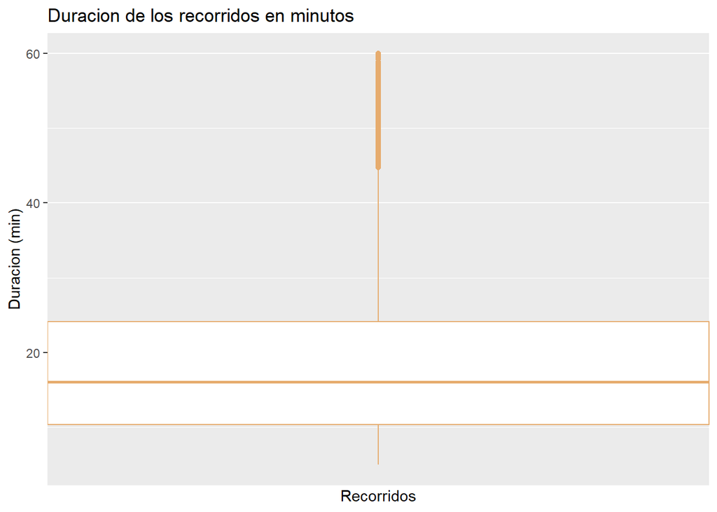

```r
gr_trips_duration_in_minutes_box
```

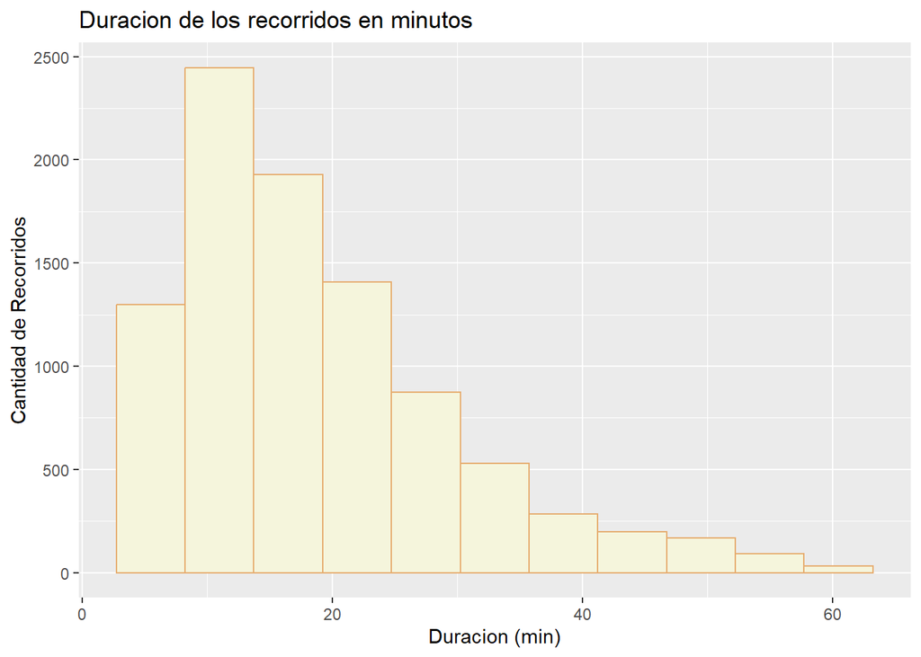

```r
gr_trips_duration_in_minutes_col
```

```r
knitr::kable(df_promedio_y_mediana_de_viajes)
```

| promedio duracion de viaje | mediana de la duracion de viajes |
| --- | --- |
| 18.71239 | 16.06667 |

#### Fecha de recorridos

En los siguientes gráficos, buscamos mostrar la cantidad de recorridos realizados durante distintos lapsos de tiempos tales como meses, días y horarios. Notamos que hay una tendencia al incremento de uso de bicis durante meses otoñales y primaverales (¿Sera debido al clima y temperaturas?) y días de semanas (¿Días de trabajo, clases?)

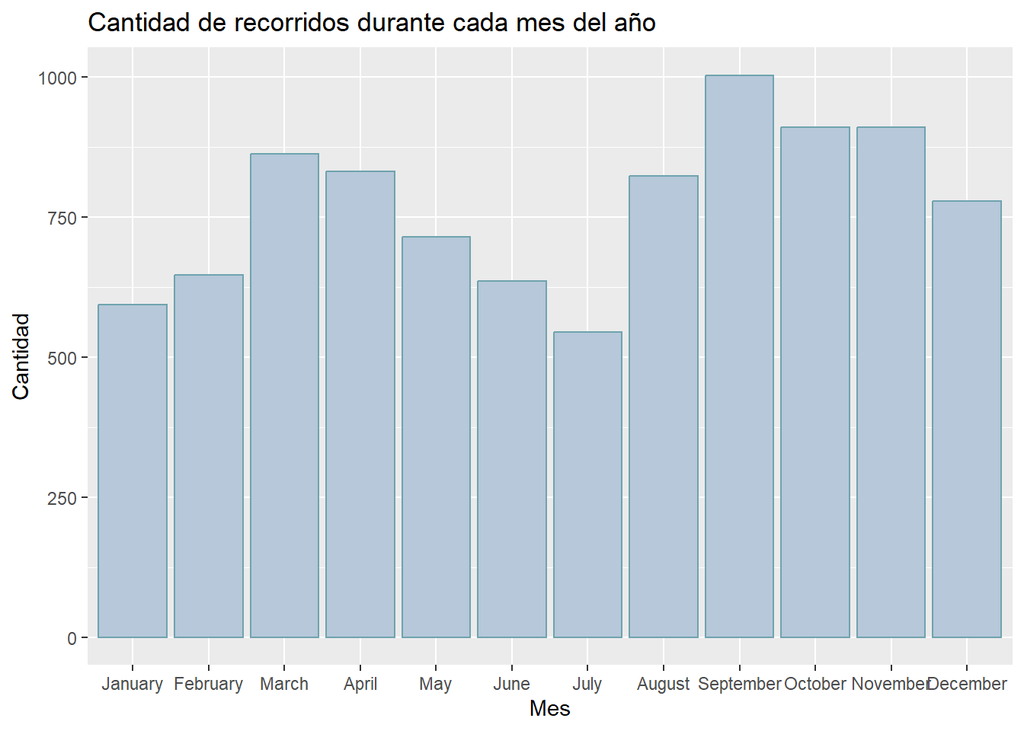

```r
gr_trips_by_month
```

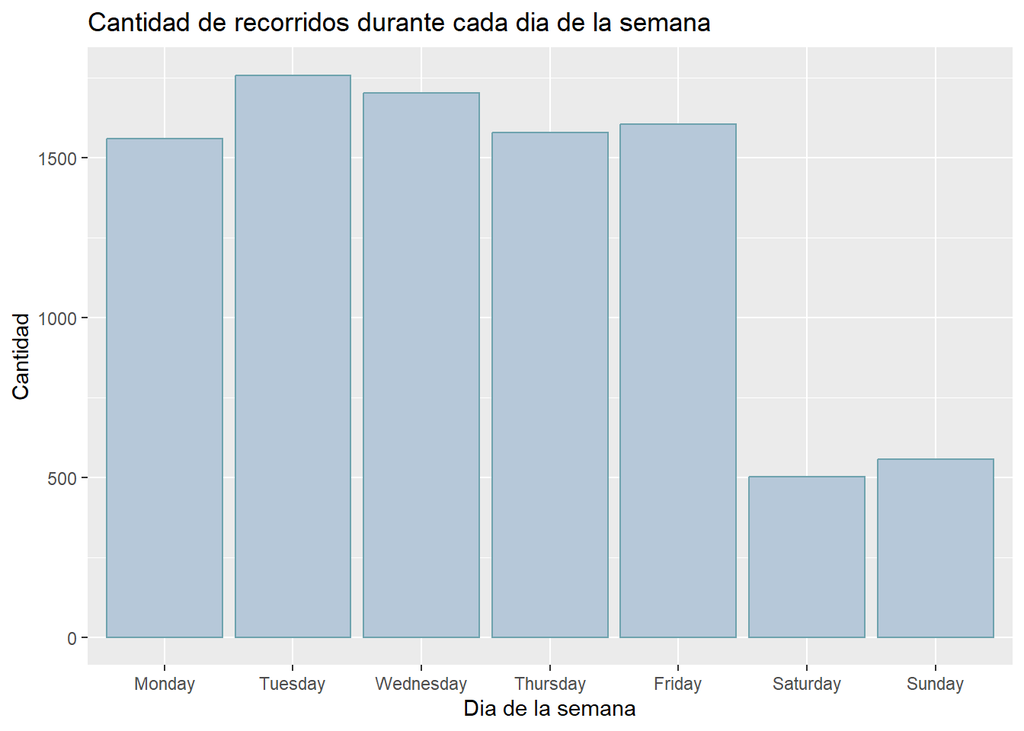

```r
gr_trips_by_day
```

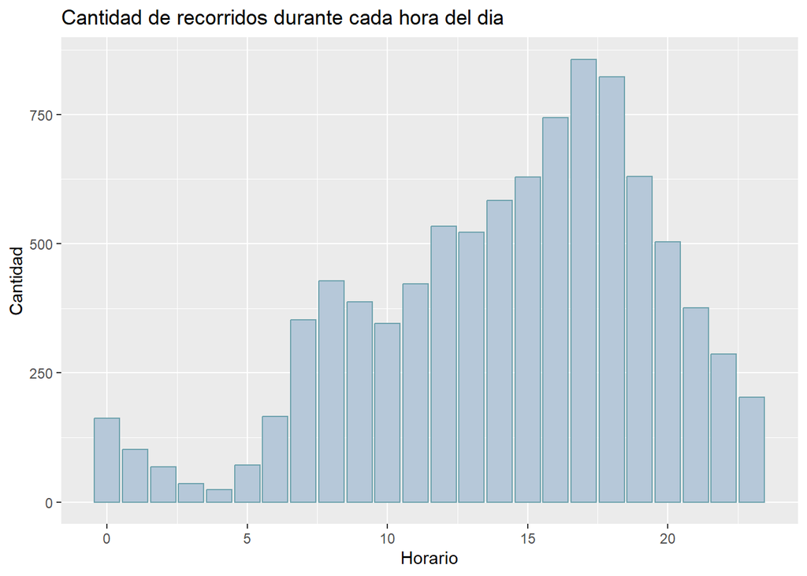

```r
gr_trips_by_hour
```

Tambien nos intereso analizar el uso de bicis según mes y día de la semana por horarios, para observar si existia algun patrón distinto. Notamos que durante los fines de semana, el uso de bicis según horarios tiene valores mas estables que comparado a los dias de semana. El gráfico que divide los horarios por mes, es un poco extenso de visualizar, por lo cual decidimos agregar un grafico que los separa por cada estación del año.

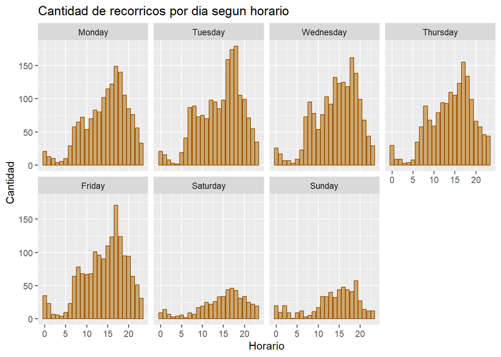

```r
gr_trips_by_day_and_hour
```

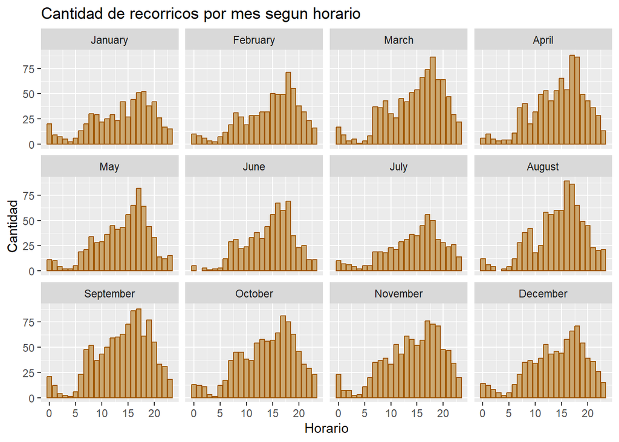

```r
gr_trips_by_month_and_hour
```

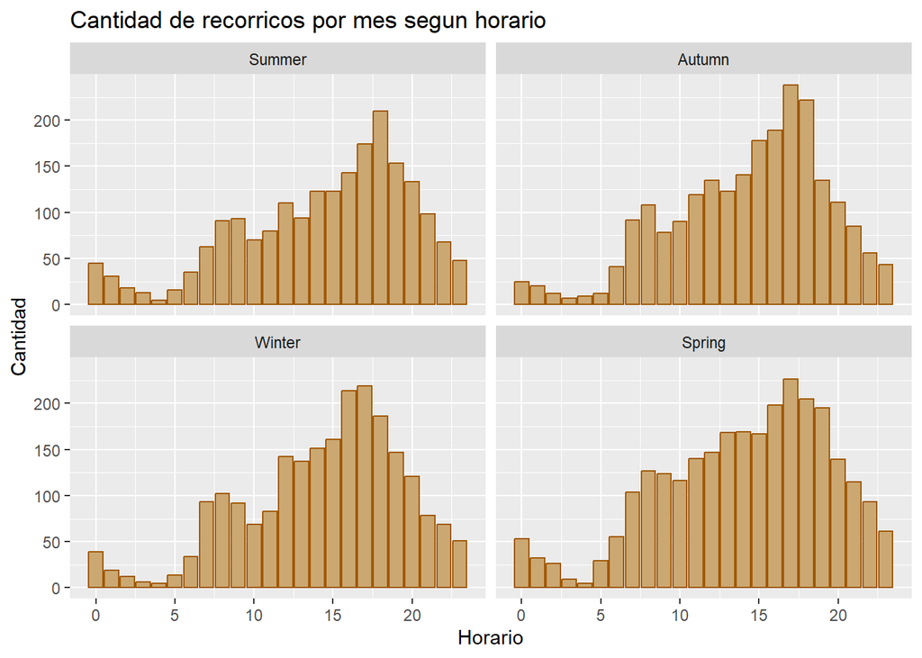

```r
gr_trips_by_season_and_hour
```

#### Feriados vs no feriados

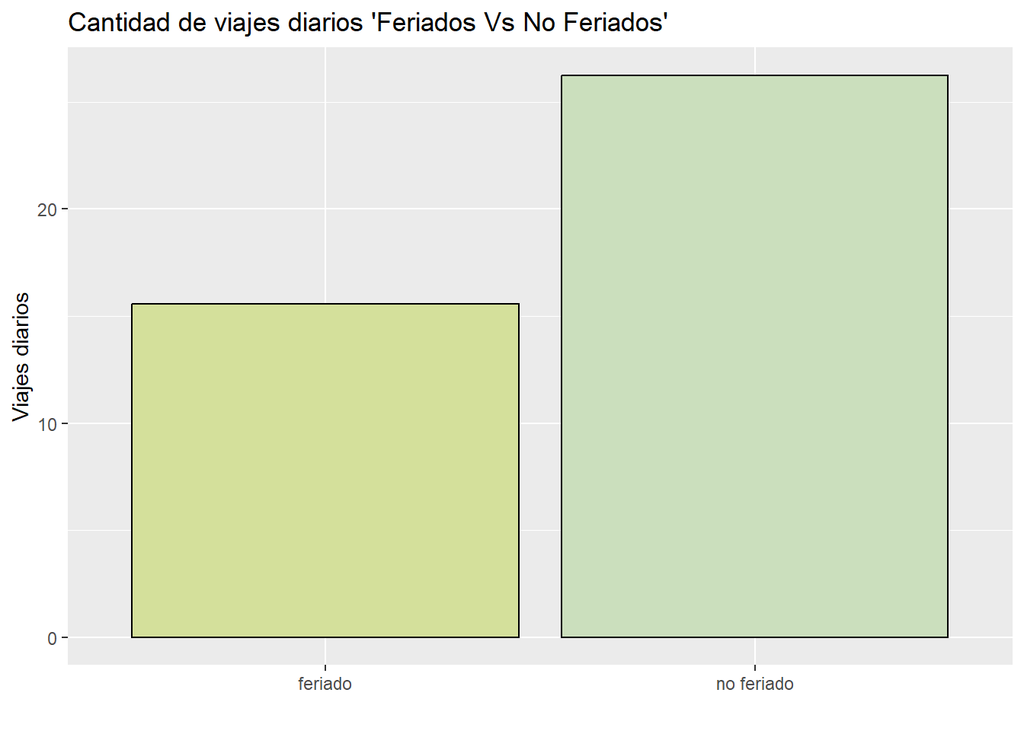

```r
gr_viajes_promedio_feriados
```

#### Estación de Origen y Destino

A la hora de decidir cuantas bicis debería haber disponible en cada estación, es conveniente preguntarse ¿Cuantas bicis se usan por estación? ¿Y cuales son los recorridos mas comunes? Las estaciones que tienen mayor frecuencia de usuarios, son aquellas que deberían tener asignadas mas bicicletas para cubrir la demanda.

```r
knitr::kable(head(df_origin_trip))
```

| id_estacion_origen | nombre_estacion_origen | amount_by_station |
| --- | --- | --- |
| 175BAEcobici | 147 - Constitución | 119 |
| 14BAEcobici | 014 - Pacifico | 111 |
| 130BAEcobici | 130 - RETIRO II | 110 |
| 54BAEcobici | 054 - Acuña de Figueroa | 101 |
| 8BAEcobici | 008 - Congreso | 97 |
| 222BAEcobici | 160 - Godoy Cruz y Libertador | 86 |

```r
knitr::kable(head(df_destination_trip))
```

| id_estacion_destino | nombre_estacion_destino | amount_by_station |
| --- | --- | --- |
| 175BAEcobici | 147 - Constitución | 125 |
| 14BAEcobici | 014 - Pacifico | 106 |
| 8BAEcobici | 008 - Congreso | 100 |
| 222BAEcobici | 160 - Godoy Cruz y Libertador | 95 |
| 131BAEcobici | 131- HOSPITAL DE CLÍNICAS | 85 |
| 5BAEcobici | 005 - Plaza Italia | 85 |

```r
knitr::kable(head(df_common_trips))
```

| id_estacion_origen | nombre_estacion_origen | id_estacion_destino | nombre_estacion_destino | amount |
| --- | --- | --- | --- | --- |
| 239BAEcobici | 391 - Plaza República de Ecuador | 14BAEcobici | 014 - Pacifico | 12 |
| 130BAEcobici | 130 - RETIRO II | 448BAEcobici | 393 - Barrio 31 | 11 |
| 14BAEcobici | 014 - Pacifico | 239BAEcobici | 391 - Plaza República de Ecuador | 11 |
| 152BAEcobici | 152 - JULIETA LANTERI | 152BAEcobici | 152 - JULIETA LANTERI | 11 |
| 281BAEcobici | 350 - Plaza Irlanda | 281BAEcobici | 350 - Plaza Irlanda | 10 |
| 150BAEcobici | 150 - RODRIGO BUENO | 128BAEcobici | 128 - PARQUE DEL BAJO | 9 |

#### Modelo de Bicicleta

A continuación, se encuentra el gráfico que diferencia la cantidad de recorridos que se realizaron con la bici ICONIC y la FIT. A su vez, una pregunta que nos surgió es si el uso de un tipo de bici sobre el otro, depende de la duracion del viaje, pero pareciera que no hay una relación entre tipo de bici y duración de recorridos.

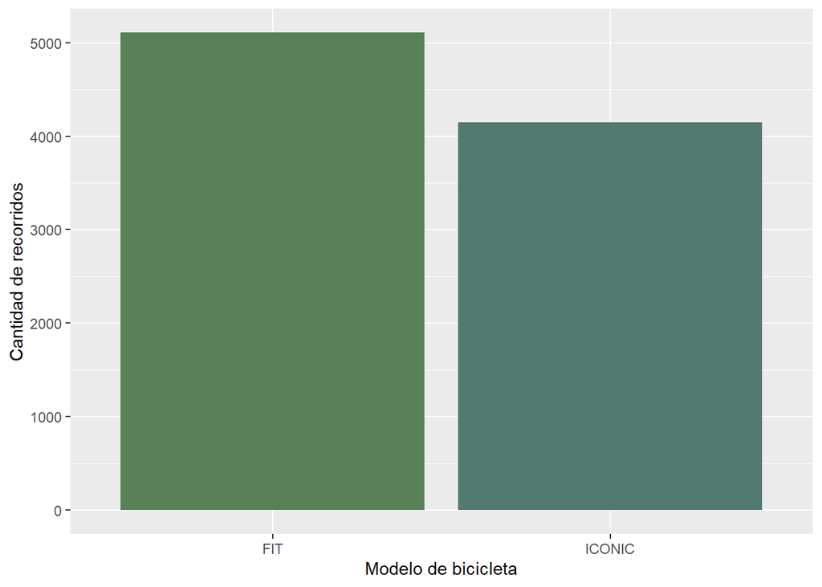

```r
gr_bike_type
```

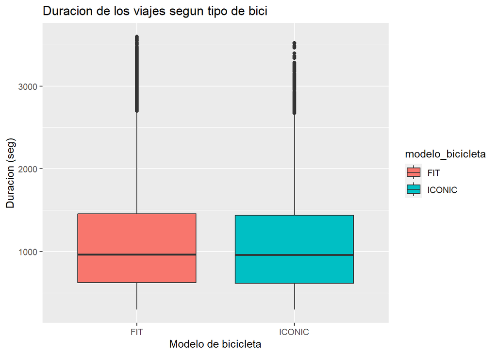

```r
gr_bike_type_boxplot
```

#### Genero

Otra pregunta que nos surgió durante el análisis fue con respecto al uso de bicis según genero ¿Hay algun genero que tienda a utilizar las bicis mas que otro? Notamos que la proporción de hombres es mucha mayor.

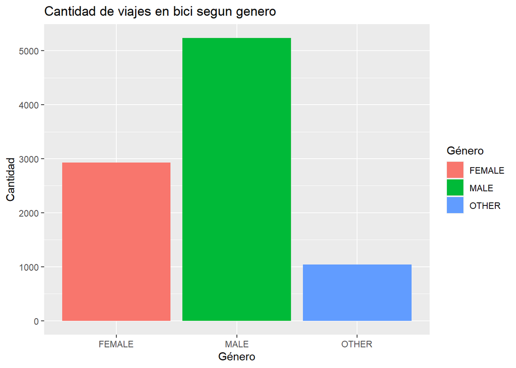

```r
gr_use_of_bikes_by_gender
```

Otra pregunta que nos interesaba analizar era el uso de bicicletas según genero y horario. Esto surge de la proposicion de que una persona de genero no masculino, quizás tienda a sentirse mas insegurx durante horarios nocturnos, en los cuales pueden ser mas vulnerables. Para esta representación usamos cantidades porcentuales, en vez de cantidad de viajes porque al haber muchos usuarios masculinos, los gráficos iban a parecer sesgados.

Notamos que pareciera que nuestra proposición estaba errónea. Solamente durante las 4 de la mañana pareciara no haber casi registros de observaciones de uso de bicis de géneros no masculinos.

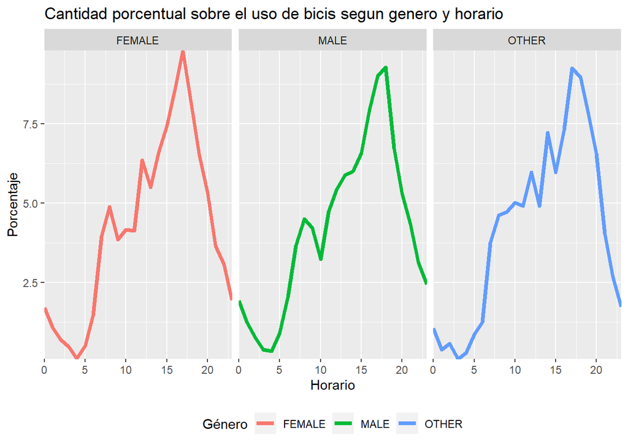

```r
gr_use_of_bikes_by_gender_per_hour
```

Otra pregunta que nos surgió durante el análisis es si la duración de los viajes es distinta en base a los generos. A partir del gráfico observamos que los valores son relativamente cercanos pero el genero femenino tiende a utilizar las bicis durante mas tiempo.

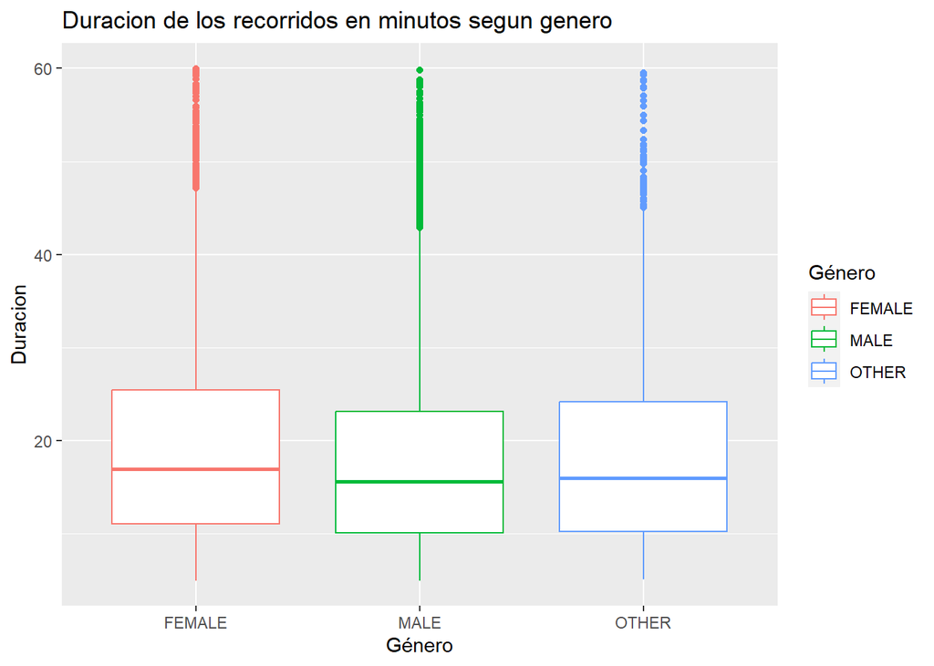

```r
gr_trips_duration_in_minutes_by_gender
```

#### Uso en días destacados del año

Durante el análisis, uno de los puntos que también nos pareció interesante indagar acerca del uso de bicis para eventos masivos que suceden en capital. ¿Los eventos incrementan el uso de bicis?

Como hemos visto antes es mucho mas común que haya viajes durante los días de semana que durante los fin de semana. Por ende, vamos a separar los eventos en 2 categorías, aquellos que ocurrieron durante días de semana y por el otro lado aquellos que ocurrieron durante el fin de semana. Notamos que algunos eventos ocurrieron durante días de semana y fines de semana, para estos casos igualmente decidimos separarlos según correspondan sus fechas.

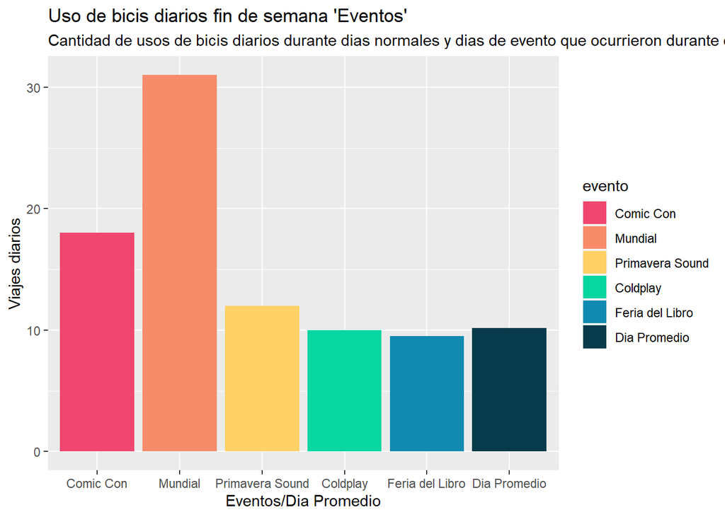

```r
gr_Eventos_Fin_De_Semana
```

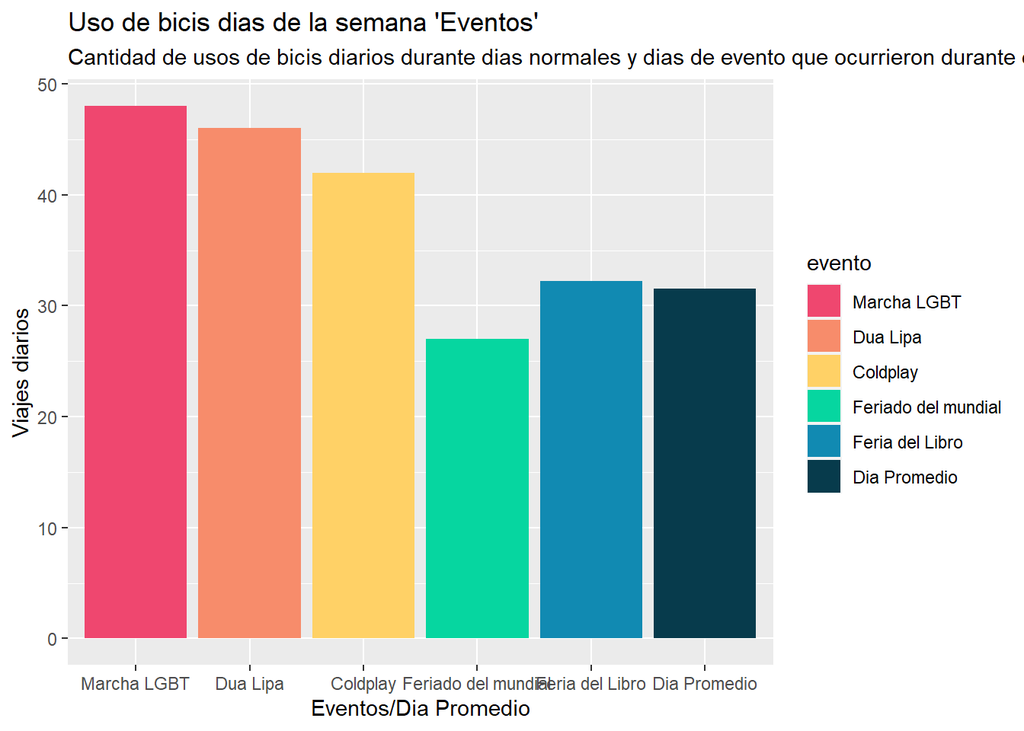

```r
gr_Eventos_Dia_De_Semana
```

## ANÁLISIS DESCRIPTIVO DE DATAFRAME VIAJES DE CLIMA AEROPARQUE 2022

Una vez hecho el análisis general, comenzamos a observar comportamientos del clima. Por ende, lo que mostraremos a continuación son algunos gráficos/dataframes que representen estas características.

#### Clima durante el año

Los siguientes gráficos representan el cambio de la temperatura. Uno en base a los días y otro en base al mes.

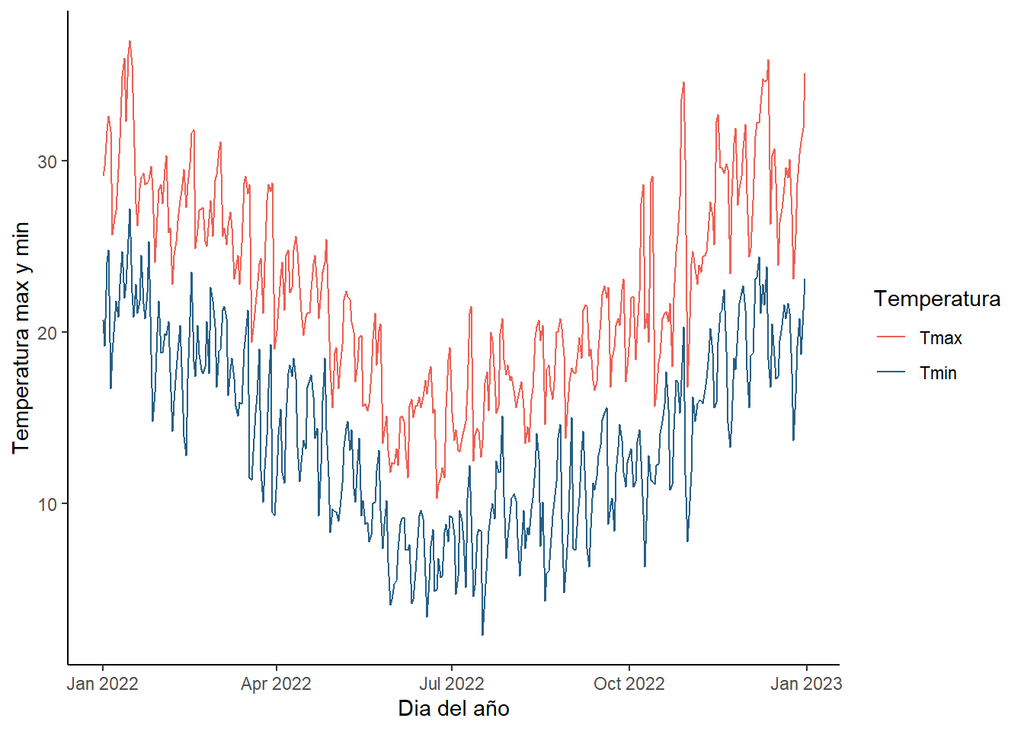

```r
gr_temperatura_por_dia
```

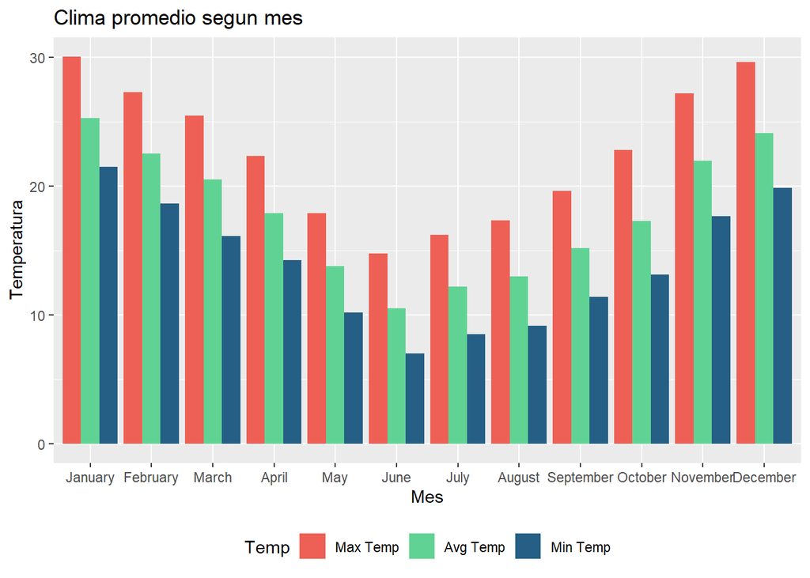

```r
gr_temperatura_por_mes
```

#### Precipitaciones durante el año

Otro tema de interés es la cantidad de precipitaciones por mes (en mm). Notamos que en febrero hay una observacion de 246.9 mm el 27 de febrero, que consultando al docente nos dijo que es posible, entonces seguimos considerandolo en nuestro analisis.

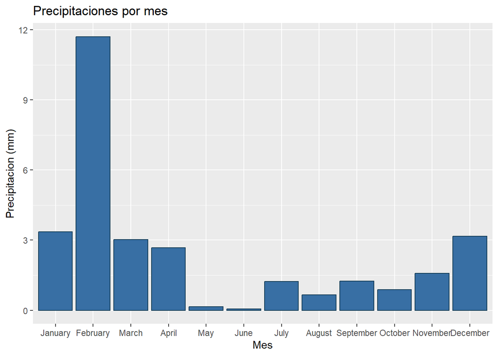

```r
gr_precipitaciones_por_mes
```

## ANÁLISIS DESCRIPTIVO DE AMBOS DATAFRAMES

### Uso de bicis por temperatura

Un tema de interés que nos surgió es el uso de bicis según temperatura promedio. ¿Sera que los dias mas calidos o frios tengan menos observaciones de usos de bicis? Notamos que este gráfico en particular tiene un problema, las temperaturas promedias durante los 365 no se distribuyen de forma equitativa,por ejemplo es mucho mas común tener un día con promedio de 20 grados que un dia con promedio de 8 grados, entonces sumar el uso de bicis dependiendo de la temperatura promedio estaría sesgado.

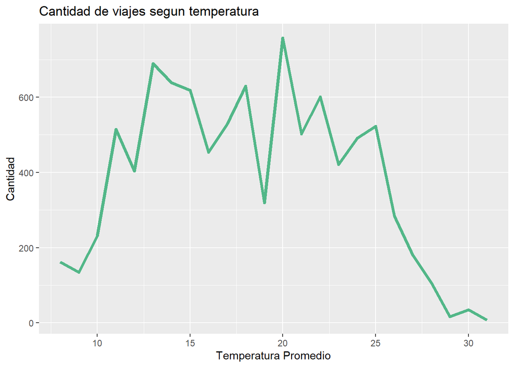

```r
gr_bikes_by_temp
```

### Uso de bicis durante lluvias

Otro pregunta que nos surgio durante el trabajo es ¿Sera que los días de lluvia tengan menos observaciones de usos de bicis? Al principio de la hipotesis nosotros pensamos que habria una gran diferencia entre uso de bicis durante dias de lluvias vs dias de no lluvia, pero nos sorprendio ver que la diferencia fuese muy poca.

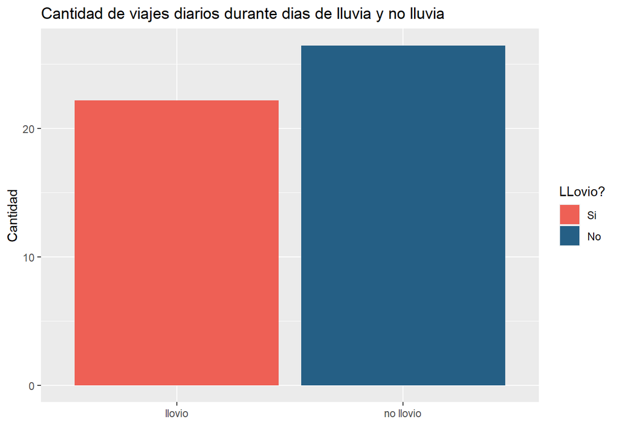

```r
gr_uso_de_bicis_segun_precipitaciones
```

Debido a que la diferncia entre uso de bicis en dias lluviosos y no lluviosos era muy poca nos llevo a pensar otra pregunta. ¿Sera que en realidad el uso de bicis depende de que tan fuerte sea la lluvia?

Separando de esta forma notamos que los dias de lluvias mas fuertes tienen una cantidad mas bajo que el de dia de lluvias debiles. Lo cual responde en cierta parte a nuestra pregunta, de que lluvias fuertes reducen el uso de bicis.

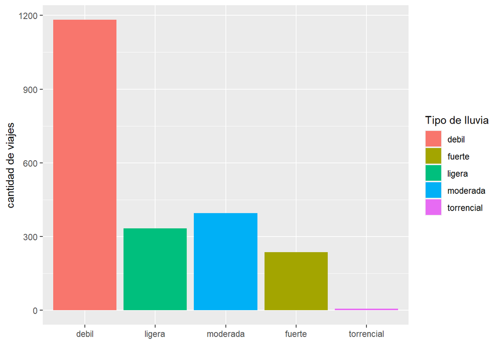

```r
gr_potencia_lluvia_2022
```

Finalmente, tambien nos intereso observar la duracion de viajes segun dias lluviosos y no lluvios. ¿Sera que los recorridos durante dias de lluvia son mas cortos? A partir del grafico observamos que la duracion se mantiene, lo cual refuta nuestra idea.

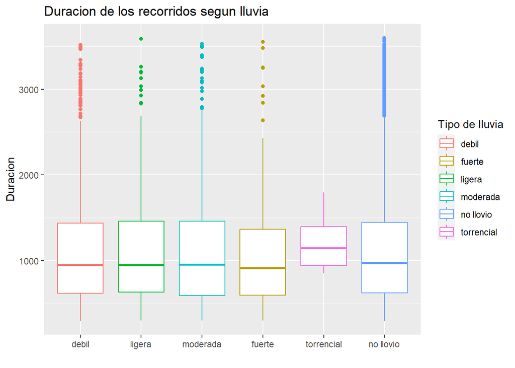

```r
gr_duracion_recorrido_segun_lluvia
```